# Pandemic pressure and product quality. A time series perspective

#### Step 3: baseline cross-correlation on stationary data

```r
###baseline cross-correlation on stationary data
baseline_ccf <- ccf(x_series_CV19_s, y_series_s, na.action = na.omit,
main = str_c("New COVID-19 cases (x) and ", product_subset, " (y)"), ylab = "baseline CCF")
```

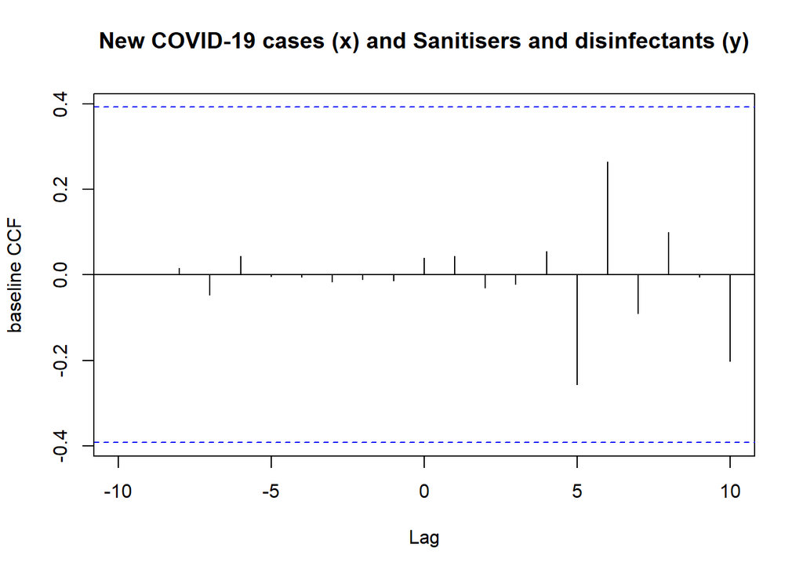

```
## # A tibble: 0 × 2
## # ℹ 2 variables: acf <dbl>, lag <dbl>
```

[output not shown]

```r
#########################################
### Additional information extraction ###
#########################################

##Extract the lags that are significant
#significance lines (CCF uses the 95% CI)
sig_line_pccf <- 1.96 / sqrt(prewhiten_ccf$n.used)

#filter lags above significance level
sig_lags_pccf <- prewhiten_ccf$acf %>%
  as.numeric() %>%
  tibble(acf = .) %>%
  mutate(lag = prewhiten_ccf$lag %>% as.numeric()) %>%
  filter(abs(acf) > sig_line_pccf)

#Range of lags analysed
min_lag <- min(prewhiten_ccf$lag)
max_lag <- max(prewhiten_ccf$lag)

#Print results
cat(
  "Significance threshold (95% CI):", sig_line_pccf, "\n",
  "The range of analysis: ", min_lag, " to ", max_lag, "\n",
    "Significant lags:",
  sep = ""
)
```

```
## Significance threshold (95% CI):0.392
## The range of analysis: -10 to 10
## Significant lags:
```

```r
sig_lags_pccf
```

```
## # A tibble: 0 × 2
## # ℹ 2 variables: acf <dbl>, lag <dbl>
```

#### Step 4: Prewhitened cross-correlation

As there is no cross-correlation detected for the baseline CCF, no need to proceed and perform prewhitening.

**Conclusion** There is no cross-correlation between the differenced x-series (cv19 cases) and the differenced y-series (MQ events for sanitizers) in the USA.

## B4. USA: Covid-19 cases & diagnostics

### B4.1. Data preparation

Prepare the dataset for USA, diagnostics , CV19 cases

### B4.2. Plotting

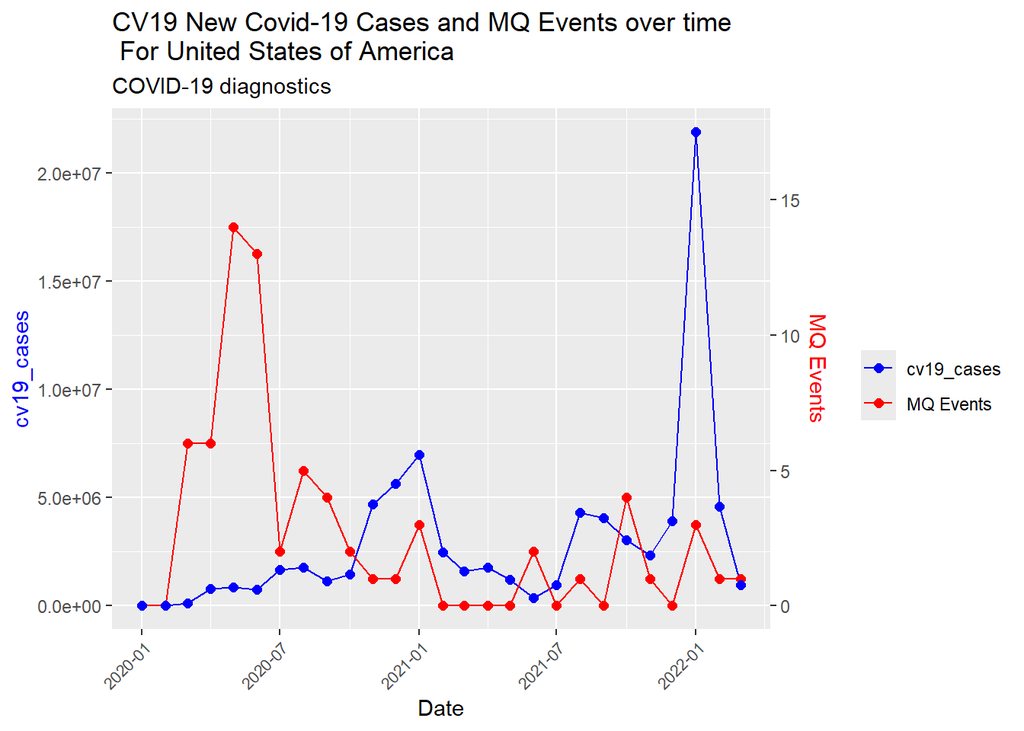

### B4.3. Cross-correlations (incl stationarity & autocorrelation)

#### Step 0: Define the time series

```r
####define the series that needs to be compared
x_series_CV19 <- joint_data$cv19_variable
y_series <- joint_data$mq_events
```

#### Step 1: Stationarity check and differencing

```r
##Check stationarity x-series
check_stationarity(x_series_CV19) #non-stationary
```

```
## ADF Statistic: -2.121729
## p-value: 0.5259864
## Alternative Hypothesis: stationary
## Non-stationary
```

```r
#1st time differencing
check_stationarity(diff(x_series_CV19)) #stationary
```

```
## ADF Statistic: -4.06336
## p-value: 0.02104559
## Alternative Hypothesis: stationary
## Stationary
```

```r
##Check stationarity y-series
check_stationarity (y_series) #non-stationary
```

```
## ADF Statistic: -2.458524
## p-value: 0.3974139
## Alternative Hypothesis: stationary
## Non-stationary
```

```r
#1st time differencing
check_stationarity(diff(y_series)) #non-stationary
```

```
## ADF Statistic: -2.871625
## p-value: 0.2403332
## Alternative Hypothesis: stationary
## Non-stationary
```

```r
#2nd time differencing
check_stationarity(diff(diff(y_series))) #stationary
```

```
## ADF Statistic: -4.868546
## p-value: 0.01
## Alternative Hypothesis: stationary
## Stationary
```

```r
##################################
### Information for dataframe  ###
##################################

# ##Check stationarity x-series
# stat_check_x <- adf_until_stationary(x_series_CV19)
# print_check_stationarity(stat_check_x)
# #Define stationary x_series
# x_series_CV19_s <- stat_check_x$transformed_series[[1]]


##Check stationarity y-series
stat_check_y <- adf_until_stationary(y_series)
print_check_stationarity(stat_check_y)
```

```
##
##  y_series
## Results original time-series:
##
##  Augmented Dickey-Fuller Test
##
## data:  time_series
## Dickey-Fuller = -2.4585, Lag order = 2, p-value = 0.3974
## alternative hypothesis: stationary
##
## Number of differencing required to obtain stationarity: 2
```

```r
#Define stationary y_series
y_series_s <- stat_check_y$transformed_series[[1]]
```

#### Step 2: Autocorrelation analysis using ACF and PACF

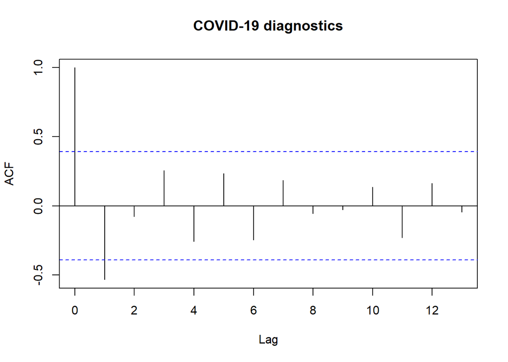

```r
# ##X-series
# acf_x <- acf(x_series_CV19_s, main= "New COVID-19 cases")
# pacf_x <- pacf(x_series_CV19_s, main= "New COVID-19 cases")

##Y-series
acf_y <- acf(y_series_s, main= product_subset)
```

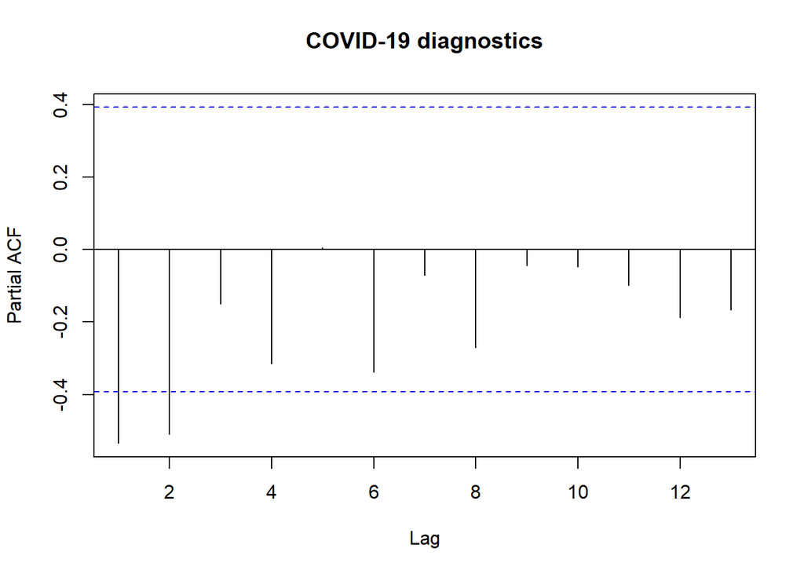

```r
pacf_y <- pacf(y_series_s, main= product_subset)
```

#### Step 3: baseline cross-correlation on stationary data

```r
###baseline cross-correlation on stationary data
baseline_ccf <- ccf(x_series_CV19_s, y_series_s, na.action = na.omit,
main = str_c("New COVID-19 cases (x) and ", product_subset, " (y)"), ylab = "baseline CCF")
```

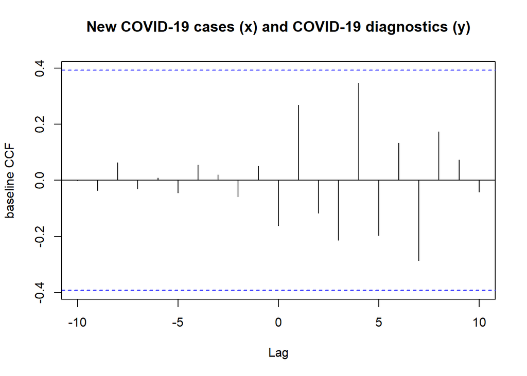

```
## # A tibble: 0 × 2
## # ℹ 2 variables: acf <dbl>, lag <dbl>
```

```
## Significance threshold (95% CI):0.392
## The range of analysis: -10 to 10
## Significant lags:
```

#### Step 4: Prewhitened cross-correlation

As there is no cross-correlation detected for the baseline CCF, no need to proceed and perform prewhitening.

## B5. USA: Covid-19 cases & ppe

Prepare the dataset for USA, PPE (personal protective equipment), CV19 cases

### B5.1. Data preparation

### B5.2. Plotting

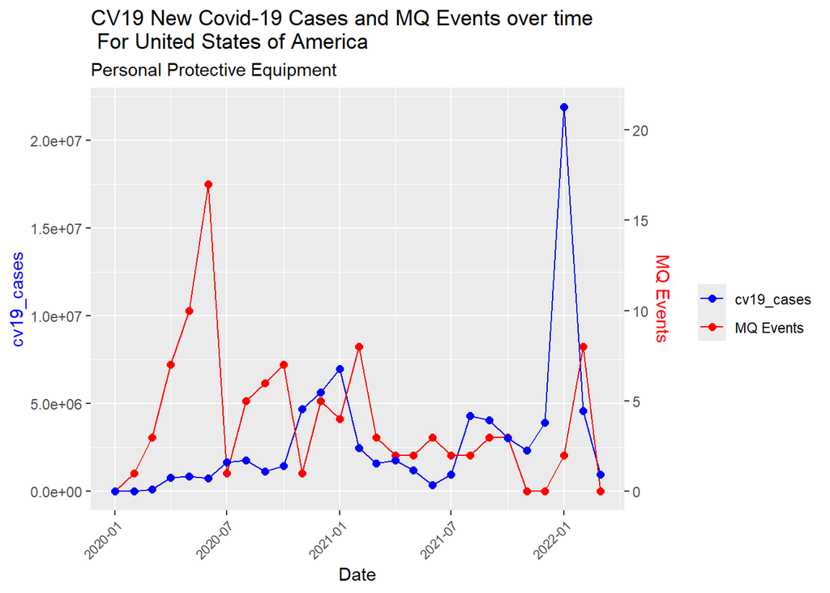

### B5.3. Cross-correlations (incl stationarity & autocorrelation)

#### Step 0: Define the time series

```r
####define the series that needs to be compared
x_series_CV19 <- joint_data$cv19_variable
y_series <- joint_data$mq_events
```

#### Step 1: Stationarity check and differencing

```r
# ##Check stationarity x-series
# check_stationarity(x_series_CV19) #non-stationary
# #1st time differencing
# check_stationarity(diff(x_series_CV19)) #stationary

##Check stationarity y-series
check_stationarity (y_series) #stationary
```

```
## ADF Statistic: -4.691
## p-value: 0.01
## Alternative Hypothesis: stationary
## Stationary
```

```r
##################################
### Information for dataframe  ###
##################################

# ##Check stationarity x-series
# stat_check_x <- adf_until_stationary(x_series_CV19)
# print_check_stationarity(stat_check_x)
# #Define stationary x_series
# x_series_CV19_s <- stat_check_x$transformed_series[[1]]


##Check stationarity y-series
stat_check_y <- adf_until_stationary(y_series)
print_check_stationarity(stat_check_y)
```

```
##
##  y_series
## Results original time-series:
##
##  Augmented Dickey-Fuller Test
##
## data:  time_series
## Dickey-Fuller = -4.691, Lag order = 2, p-value = 0.01
## alternative hypothesis: stationary
##
## Number of differencing required to obtain stationarity: 0
```

```r
#Define stationary y_series
y_series_s <- stat_check_y$transformed_series[[1]]
```

#### Step 2: Autocorrelation analysis using ACF and PACF

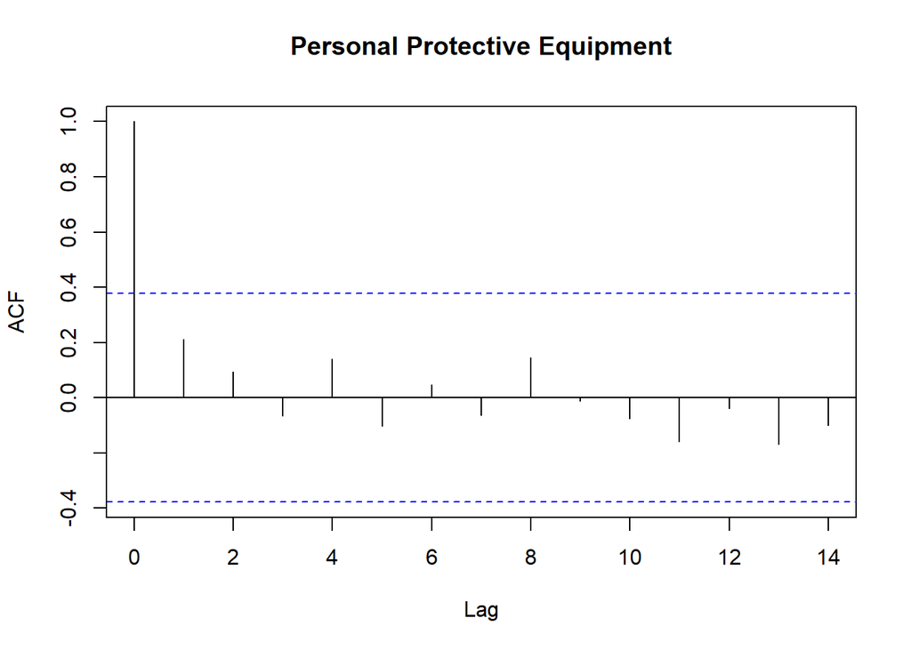

```r
# ##X-series
# acf_x <- acf(x_series_CV19_s, main= "New COVID-19 cases")
# pacf_x <- pacf(x_series_CV19_s, main= "New COVID-19 cases")

##Y-series
acf_y <- acf(y_series_s, main= product_subset)
```

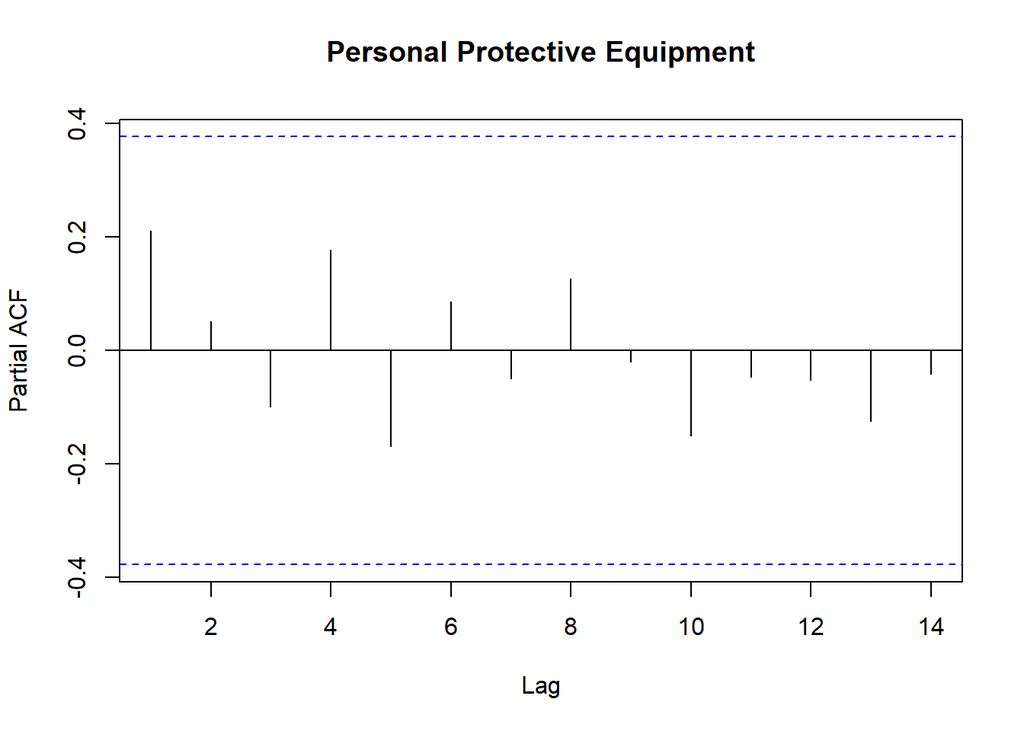

```r
pacf_y <- pacf(y_series_s, main= product_subset)
```

No ACF or PACF thus no need to perform prewhitening.

#### Step 3: baseline cross-correlation on stationary data

```r
###baseline cross-correlation on stationary data
baseline_ccf <- ccf(x_series_CV19_s, y_series_s, na.action = na.omit,
main = str_c("New COVID-19 cases (x) and ", product_subset, " (y)"), ylab = "baseline CCF")
```

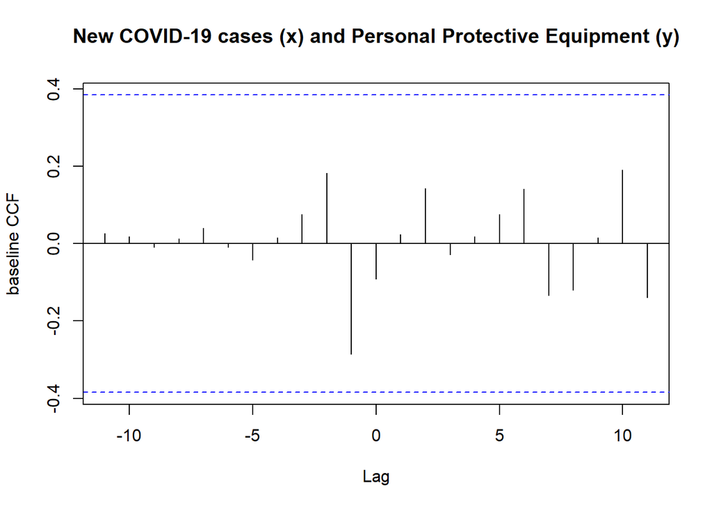

```
## # A tibble: 0 × 2
## # ℹ 2 variables: acf <dbl>, lag <dbl>
```

```
## Significance threshold (95% CI):0.3843876
## The range of analysis: -11 to 11
## Significant lags:
```

#### Step 4: Prewhitened cross-correlation

No ACF/PACF (ánd no cross-correlation detected for the baseline CCF) Thus no need to proceed and perform prewhitening.